# Integrative Analysis of Common Variable Immunodeficiency (CVID)

Ian Mc Farlane, Bram Stults, advised by W. Evan Johnson, Ph.D.

2025-04-01

# Review

# Methods

- We analyzed:
  - Nasopharyngeal Samples from Dr Johnson
  - PBMC Samples with LPS stimulated and control groups from Dr Maglione.
- We compared the results of the first analysis to the results of each of the groups of the second analysis:
  - Nasopharyngeal vs LPS stimulated
  - Nasopharyngeal vs Control (LPS UNstimulated)

# Results summary

- We identified the following types of pathways to be significantly affected in both comparisons:
  - Focal adhesion
  - Inflammation
  - Chemokine receptors
- Overarching Genes:
  - ITGA4: Encodes integrin alpha-4, a cell adhesion molecule involved in leukocyte trafficking and immune cell migration.
  - GPR55: Encodes a G protein-coupled receptor implicated in inflammatory responses, pain signaling, and cancer progression.
  - CCR4: Encodes a chemokine receptor that regulates immune cell trafficking, particularly T-cell migration to inflammation sites.

# Nasal VS Control (Unstimulated) - Combined DEGs (DeSeq)

|  | combined_p | nasal_effect | ctrl_effect | reg_agreement |
| --- | --- | --- | --- | --- |
| ITGA4 | 3.106381476269959e-06 | Upregulated | Upregulated | Same |
| SEMA7A | 0.0002305980391501539 | Upregulated | Downregulated | Opposite |
| TNIP3 | 0.0006933075956957468 | Upregulated | Downregulated | Opposite |
| TNFRSF9 | 0.0007953447415084414 | Upregulated | Downregulated | Opposite |
| PDGFA | 0.002128631982435403 | Downregulated | Downregulated | Same |
| MEI1 | 0.003210603628079567 | Upregulated | Downregulated | Opposite |
| CA12 | 0.003955102549331513 | Downregulated | Downregulated | Same |
| HLA-DRB6 | 0.00545163933233761 | Upregulated | Upregulated | Same |
| GPR55 | 0.007695772287513725 | Upregulated | Downregulated | Opposite |
| SLCO4A1 | 0.00864615354677345 | Upregulated | Downregulated | Opposite |

[output cut: 23 more lines]

# Nasal VS Control (Unstimulated) - Combined Pathways

|  | Term | Overlap | P.value | Old.P.value | Odds.Ratio | Combined.Score | Genes | database |
| --- | --- | --- | --- | --- | --- | --- | --- | --- |
| 1 | Focal Adhesion Mus musculus WP85 | 3/185 | 0.00346413928846352 | 0 | 10.87087912087912 | 61.58669450217408 | ITGA4;COL5A1;PDGFA | WikiPathways |
| 2 | Focal Adhesion Homo sapiens WP306 | 3/191 | 0.003788703783790677 | 0 | 10.52074468085106 | 58.66084571028274 | ITGA4;COL5A1;PDGFA | WikiPathways |
| 3 | Integrin signalling pathway Homo sapiens P00034 | 2/156 | 0.02725172120722962 | 0 | 8.300377042312526 | 29.90325869647388 | ITGA4;COL5A1 | Panther |
| 4 | Inflammation mediated by chemokine and cytokine signaling pathway Homo sapiens P00031 | 2/188 | 0.03835318674200439 | 0 | 6.861255636489767 | 22.37398966348209 | CCR4;RELB | Panther |
| 5 | Focal Adhesion-PI3K-Akt-mTOR-signaling pathway Mus musculus WP2841 | 3/303 | 0.01342826926896574 | 0 | 6.555666666666666 | 28.25750067577217 | ITGA4;COL5A1;PDGFA | WikiPathways |
| 6 | EV release from cardiac cells and their functional effects Homo sapiens WP3297 | 1/9 | 0.01475516971784237 | 0 | 77.96484375 | 328.7123934869669 | RGS16 | WikiPathways |
| 7 | Hemostasis Homo sapiens R-HSA-109582 | 5/552 | 0.00196923029858154 | 0 | 6.339775398276313 | 39.49751410789315 | APBB1IP;DOCK11;ITGA4;PDPN;PDGFA | Reactome |
| 8 | G alpha (i) signalling events Homo sapiens R-HSA-418594 | 3/240 | 0.00713948515193767 | 0 | 8.324894514767932 | 41.1425828314721 | RGS16;GPR55;CCR4 | Reactome |
| 9 | Platelet activation, signaling and aggregation Homo sapiens R-HSA-76002 | 3/253 | 0.008248592620827304 | 0 | 7.8868 | 37.83860040092529 | APBB1IP;PDPN;PDGFA | Reactome |
| 10 | Extracellular matrix organization Homo sapiens R-HSA-1474244 | 3/283 | 0.01117922959133043 | 0 | 7.031071428571429 | 31.59550967002172 | ITGA4;COL5A1;PDGFA | Reactome |

[output cut: 221 more lines]

# Nasal VS LPS Stimulated - Combined DEGs (DeSeq)

|  | combined_p | nasal_effect | lps_effect | reg_agreement |
| --- | --- | --- | --- | --- |
| GPR55 | 0.006391245530125933 | Upregulated | Downregulated | Opposite |
| CXCR3 | 0.01032621587267257 | Upregulated | Upregulated | Same |
| ITGA4 | 0.01363674630974898 | Upregulated | Upregulated | Same |
| CCR4 | 0.02294138157204006 | Upregulated | Downregulated | Opposite |
| TIGIT | 0.05035676003730361 | Upregulated | Upregulated | Same |
| ZNF683 | 0.1213041794017983 | Upregulated | Upregulated | Same |
| TPSB2 | 0.128685177707643 | Downregulated | Upregulated | Opposite |

# Nasal VS LPS Stimulated - Combined Pathways

|  | Term | Overlap | P.value | Old.P.value | Odds.Ratio | Combined.Score | Genes | database |
| --- | --- | --- | --- | --- | --- | --- | --- | --- |
| 1 | G alpha (i) signalling events Homo sapiens R-HSA-418594 | 3/240 | 5.763838405981794e-05 | 0 | 62.51898734177215 | 610.2679554457255 | CXCR3;GPR55;CCR4 | Reactome |
| 2 | Class A/1 (Rhodopsin-like receptors) Homo sapiens R-HSA-373076 | 3/323 | 0.0001391999152647006 | 0 | 46.10859375 | 409.4258422639427 | CXCR3;GPR55;CCR4 | Reactome |
| 3 | Chemokine receptors bind chemokines Homo sapiens R-HSA-380108 | 2/56 | 0.0001602524572897448 | 0 | 147.6962962962963 | 1290.682505153888 | CXCR3;CCR4 | Reactome |
| 4 | GPCR ligand binding Homo sapiens R-HSA-500792 | 3/447 | 0.0003630015187573662 | 0 | 33.02195945945946 | 261.5703599655748 | CXCR3;GPR55;CCR4 | Reactome |
| 5 | Peptide GPCRs Mus musculus WP234 | 2/66 | 0.0002228372388395047 | 0 | 124.55625 | 1047.402091123161 | CXCR3;CCR4 | WikiPathways |
| 6 | Peptide GPCRs Homo sapiens WP24 | 2/74 | 0.0002802244447482213 | 0 | 110.6722222222222 | 905.2898894159164 | CXCR3;CCR4 | WikiPathways |
| 7 | GPCRs, Other Homo sapiens WP117 | 2/93 | 0.0004424317906880564 | 0 | 87.48131868131868 | 675.6378419258923 | CXCR3;GPR55 | WikiPathways |
| 8 | Inflammation mediated by chemokine and cytokine signaling pathway Homo sapiens P00031 | 2/188 | 0.001789310350911325 | 0 | 42.59569892473118 | 269.4571972396255 | CXCR3;CCR4 | Panther |
| 9 | Chemokine signaling pathway Mus musculus WP2292 | 2/165 | 0.001382557592621806 | 0 | 48.66257668711656 | 320.3856537766379 | CXCR3;CCR4 | WikiPathways |
| 10 | GPCRs, Class A Rhodopsin-like Mus musculus WP189 | 2/171 | 0.00148376490393311 | 0 | 46.9207100591716 | 305.6026815964338 | CXCR3;CCR4 | WikiPathways |

[output cut: 36 more lines]

# Update

# Methods

- We replicated this sort of analysis with Tuberculosis data provided by Dr Johnson
  - Blood and Nasal groups.
- We compared the results from the Blood and Nasal groups using similar techniques.
- We tried to compare the results to the previous analysis once more, but the DEG overlap was not significant enough to perform any meaningful analisys.

# Data Visualization

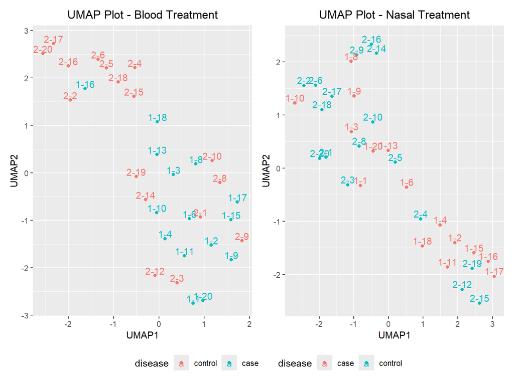

# Combined DEGs (DeSeq)

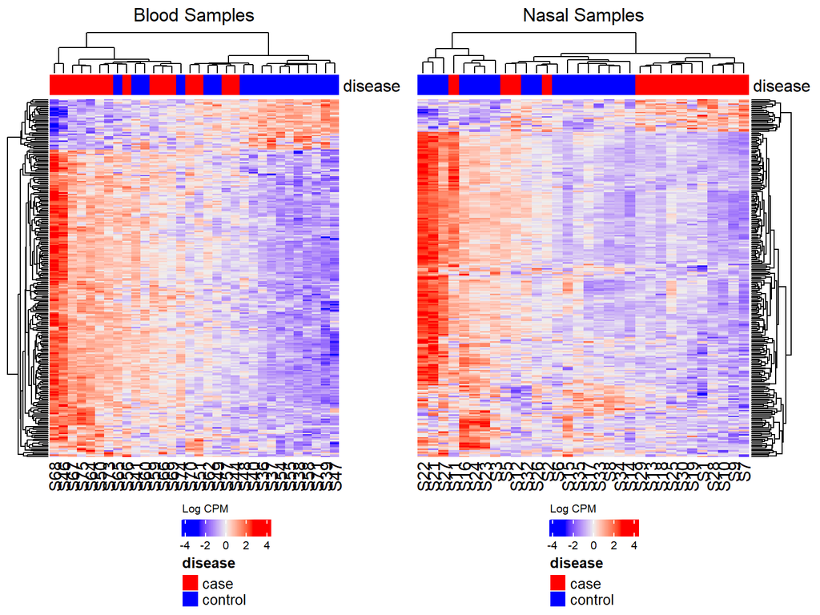

# Blood Genes

|  | ctrl_padj | ctrl_effect |
| --- | --- | --- |
| METTL7B | 4.305735363579061e-05 | Downregulated |
| IL18R1 | 0.000452197624583062 | Downregulated |
| APOL4 | 0.000496572578979658 | Downregulated |
| ITGA7 | 0.000496572578979658 | Downregulated |
| MAOB | 0.001760784779425399 | Downregulated |
| COL4A2 | 0.001760784779425399 | Downregulated |
| PFKFB2 | 0.002058197626252327 | Downregulated |
| CNIH4 | 0.002058197626252327 | Downregulated |
| NAP1L5 | 0.002058197626252327 | Downregulated |
| C1QTNF7 | 0.002261063549221119 | Downregulated |

[output cut: 240 more lines]

# Blood Pathways

|  | Term | Overlap | P.value | Old.P.value | Odds.Ratio | Combined.Score | Genes | database |
| --- | --- | --- | --- | --- | --- | --- | --- | --- |
| 1 | Extracellular matrix organization Homo sapiens R-HSA-1474244 | 13/283 | 6.11208844685799e-05 | 0 | 3.95749335833724 | 38.39820040695498 | ITGAM;PCOLCE2;COL23A1;PLOD1;MMP8;MMP9;LOXL1;ADAMTS2;COL4A2;ITGAD;ITGAX;ITGA7;CEACAM8 | Reactome |
| 2 | Collagen formation Homo sapiens R-HSA-1474290 | 7/85 | 9.442303296720808e-05 | 0 | 7.265168302205339 | 67.33158569072582 | ADAMTS2;COL4A2;PCOLCE2;COL23A1;PLOD1;MMP9;LOXL1 | Reactome |
| 3 | Integrin cell surface interactions Homo sapiens R-HSA-216083 | 6/67 | 0.0001895054272689101 | 0 | 7.936979306638 | 68.0285869342391 | ITGAM;ITGAD;COL4A2;COL23A1;ITGAX;ITGA7 | Reactome |
| 4 | 5-Hydroxytryptamine degredation Homo sapiens P04372 | 2/5 | 0.001518052141046532 | 0 | 53.08333333333334 | 344.5282049647442 | MAOB;ALDH1A2 | Panther |
| 5 | NOD-like receptor signaling pathway Homo sapiens hsa04621 | 5/57 | 0.0007227295414911713 | 0 | 7.730769230769231 | 55.91259893360589 | CASP5;CCL2;NLRC4;MAPK14;NAIP | KEGG |
| 6 | Hematopoietic cell lineage Homo sapiens hsa04640 | 6/88 | 0.0008277248652302772 | 0 | 5.898040783686525 | 41.85739128367812 | ITGAM;CR1;FLT3;ANPEP;IL1R2;FCGR1A | KEGG |
| 7 | Focal Adhesion-PI3K-Akt-mTOR-signaling pathway Mus musculus WP2841 | 12/303 | 0.0004556578468914185 | 0 | 3.371567183574461 | 25.94005694034708 | IFNAR2;PFKFB2;PFKFB3;ITGAM;COL4A2;ITGAD;ITGAX;ITGA7;SLC2A3;JAK3;FGFR2;CREB5 | WikiPathways |
| 8 | Cytokine-cytokine receptor interaction Homo sapiens hsa04060 | 10/265 | 0.001919148343364385 | 0 | 3.185457516339869 | 19.92782009807239 | IFNAR2;IL18RAP;IL10RB;FLT3;IL1R2;CCL2;LTBR;ACVR1B;IL18R1;TNFRSF21 | KEGG |
| 9 | TNF signaling pathway Homo sapiens hsa04668 | 6/110 | 0.002606952674319744 | 0 | 4.645176544766708 | 27.63681833294502 | SOCS3;CCL2;MAPK14;MMP9;IL18R1;CREB5 | KEGG |
| 10 | Renin-angiotensin system Homo sapiens hsa04614 | 3/23 | 0.002840491504490116 | 0 | 11.98178137651822 | 70.25850815507653 | CTSA;ACE2;ANPEP | KEGG |

[output cut: 980 more lines]

# Nasal Genes

|  | ctrl_padj | ctrl_effect |
| --- | --- | --- |
| CST1 | 7.562078139209943e-12 | Upregulated |
| CLC | 4.454137036639599e-06 | Upregulated |
| CLEC12A | 2.237312507205849e-05 | Upregulated |
| LGALS12 | 0.0001234023443658687 | Upregulated |
| CD69 | 0.001472539538354095 | Upregulated |
| CEACAM21 | 0.002755556957463955 | Upregulated |
| CEBPE | 0.003500436488693598 | Upregulated |
| SPIB | 0.003500436488693598 | Upregulated |
| VSTM1 | 0.004104926325453687 | Upregulated |
| FETUB | 0.004234184739905364 | Upregulated |

[output cut: 240 more lines]